# Assignment3

Victoria Barrera

2025-08-31

```r
library(tidyverse)
data <- read_csv("C:/Users/barre/Downloads/animal_shelter.csv")
```

## Question 1: Plot Data

### This histogram shows the age distribution of animals when they leave the shelter (via adoption, return to owner, etc.). Most animals are between 0 and 10 years old, with fewer older animals.

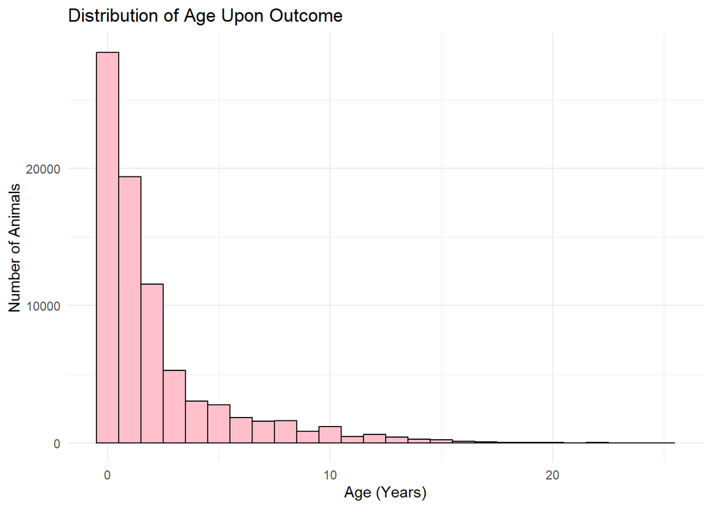

```r
ggplot(data, aes(x = age_upon_outcome_years)) +
  geom_histogram(binwidth = 1, fill = "pink", color = "black") +
  labs(
    title = "Distribution of Age Upon Outcome",
    x = "Age (Years)",
    y = "Number of Animals"
  ) +
  theme_minimal()
```

## Question 2: Statistical Calculation and Visualization

### I calculated the average age of animals for each outcome type using the `age_upon_outcome_years` column. The goal is to explore whether age plays a role in what happens to animals after they enter the shelter

.

```r
mean_age_outcome <- data %>%
  group_by(outcome_type) %>%
  summarise(mean_age = mean(age_upon_outcome_years, na.rm = TRUE)) %>%
  arrange(desc(mean_age))
```

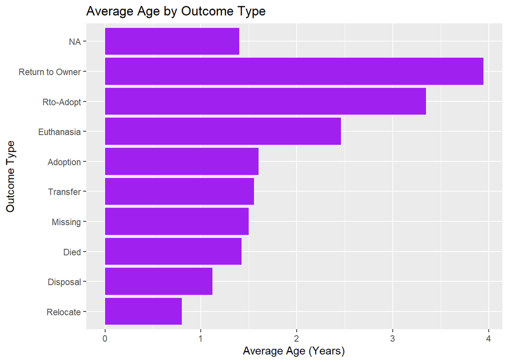

```r
ggplot(mean_age_outcome, aes(x = reorder(outcome_type, mean_age), y = mean_age)) +
  geom_col(fill = "purple") +
  coord_flip() +
  labs(
    title = "Average Age by Outcome Type",
    x = "Outcome Type",
    y = "Average Age (Years)"
  )
```

## Question 3: Correlation or Regression Analysis.

### To answer the question “Do older animals tend to stay longer or shorter in the shelter?”I will test the correlation Between age_upon_intake_years and time_in_shelter_days. Since our resulting p-value is less than 2.2e-16, we reject the null hypothesis that there is no correlation between an animal’s age at intake and the amount of time it spends in the shelter.

```r
cor_test <- cor.test(data$age_upon_intake_years,data$time_in_shelter_days)

cor_test
```

```
##
##  Pearson's product-moment correlation
##
## data:  data$age_upon_intake_years and data$time_in_shelter_days
## t = 10.702, df = 79670, p-value < 2.2e-16
## alternative hypothesis: true correlation is not equal to 0
## 95 percent confidence interval:
##  0.03095172 0.04481936
## sample estimates:
##        cor
## 0.03788737
```

## Question 4:

### The histogram shows a right-skewed distribution of time_in_shelter_days, meaning that the majority of animals stay in the shelter for a short period, typically between 0 and 10 days.

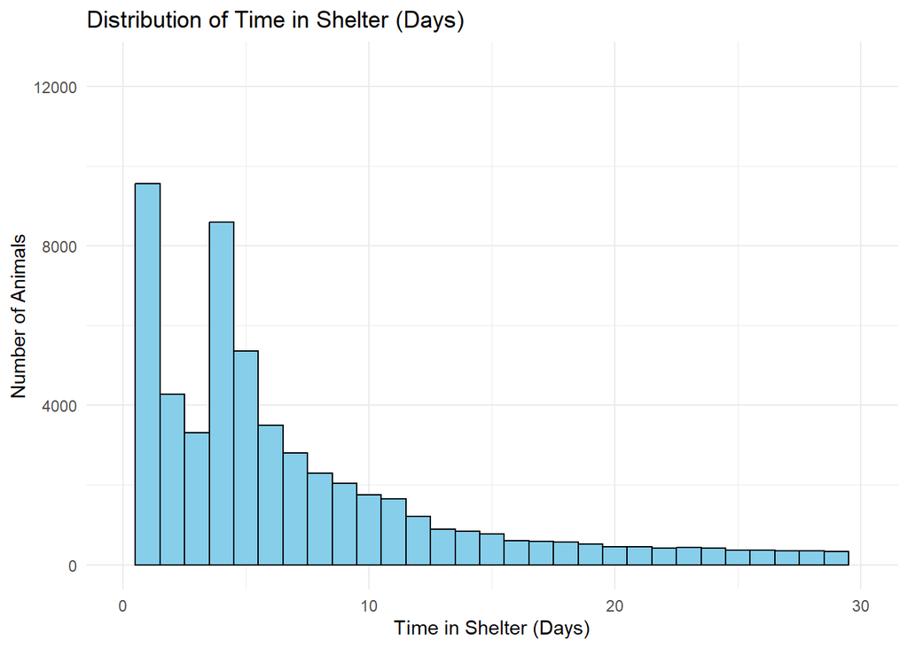

```r
library(ggplot2)

ggplot(data, aes(x = time_in_shelter_days)) +
  geom_histogram(binwidth = 1, fill = "skyblue", color = "black") +
  labs(title = "Distribution of Time in Shelter (Days)",
       x = "Time in Shelter (Days)",
       y = "Number of Animals") +
  theme_minimal() +
  xlim(0, 30)
```

## Question 5: Group Comparison Test

### To determine whether dogs and cats spend significantly different amounts of time in the shelter I first divided the data set in two rows: Dogs and cats based on the column time_in_shelter_days. The Shapiro-Wilk test showed that the data is not normally distributed,so I used the Wilcoxon rank-sum test. The test result ( p < 0.001) indicates that there is a statistically significant difference in shelter time between cats and dogs.

```r
dog_cat_data <- data %>% filter(animal_type %in% c("Dog","Cat"))

shapiro.test(sample(dog_cat_data$time_in_shelter_days[dog_cat_data$animal_type == "Dog"], 5000))
```

```
##
##  Shapiro-Wilk normality test
##
## data:  sample(dog_cat_data$time_in_shelter_days[dog_cat_data$animal_type == "Dog"], 5000)
## W = 0.29392, p-value < 2.2e-16
```

```r
shapiro.test(sample(dog_cat_data$time_in_shelter_days[dog_cat_data$animal_type == "Cat"], 5000))
```

```
##
##  Shapiro-Wilk normality test
##
## data:  sample(dog_cat_data$time_in_shelter_days[dog_cat_data$animal_type == "Cat"], 5000)
## W = 0.53485, p-value < 2.2e-16
```

```r
wilcox.test(time_in_shelter_days ~ animal_type, data = dog_cat_data)
```

```
##
##  Wilcoxon rank sum test with continuity correction
##
## data:  time_in_shelter_days by animal_type
## W = 691971328, p-value = 3.318e-14
## alternative hypothesis: true location shift is not equal to 0
```